# Assignment 7: Time Series Analysis

Leonardo Rueda

## OVERVIEW

This exercise accompanies the lessons in Environmental Data Analytics on time series analysis.

## Directions

1. Change “Student Name” on line 3 (above) with your name.
2. Work through the steps, **creating code and output** that fulfill each instruction.
3. Be sure to **answer the questions** in this assignment document.
4. When you have completed the assignment, **Knit** the text and code into a single PDF file.
5. After Knitting, submit the completed exercise (PDF file) to the dropbox in Sakai. Add your last name into the file name (e.g., “Fay_A07_TimeSeries.Rmd”) prior to submission.

The completed exercise is due on Friday, November 4 at 11:59 pm.

## Set up

1. Set up your session:
- Check your working directory
- Load the tidyverse, lubridate, zoo, and trend packages
- Set your ggplot theme
2. Import the ten datasets from the Ozone_TimeSeries folder in the Raw data folder. These contain ozone concentrations at Garinger High School in North Carolina from 2010-2019 (the EPA air database only allows downloads for one year at a time). Import these either individually or in bulk and then combine them into a single dataframe named `GaringerOzone` of 3589 observation and 20 variables.

```r
# 1

getwd()
```

```
## [1] "C:/Users/leor9/OneDrive/Leonardo/MIDP Courses Fall 2022/R Class/EDA-Fall2022"
```

```r
library(tidyverse)
library(lubridate)
library(trend)
library(zoo)
library(Kendall)
library(tseries)
mytheme <- theme_classic(base_size = 11) + theme(axis.text = element_text(color = "black"),
    legend.position = "right")

theme_set(mytheme)


# 2

EPAair_O3_GaringerNC2010 <- read.csv("./Data/Raw/Ozone_TimeSeries/EPAair_O3_GaringerNC2010_raw.csv",
    stringsAsFactors = TRUE)

EPAair_O3_GaringerNC2011 <- read.csv("./Data/Raw/Ozone_TimeSeries/EPAair_O3_GaringerNC2011_raw.csv",
    stringsAsFactors = TRUE)

EPAair_O3_GaringerNC2012 <- read.csv("./Data/Raw/Ozone_TimeSeries/EPAair_O3_GaringerNC2012_raw.csv",
    stringsAsFactors = TRUE)

EPAair_O3_GaringerNC2013 <- read.csv("./Data/Raw/Ozone_TimeSeries/EPAair_O3_GaringerNC2013_raw.csv",
    stringsAsFactors = TRUE)

EPAair_O3_GaringerNC2014 <- read.csv("./Data/Raw/Ozone_TimeSeries/EPAair_O3_GaringerNC2014_raw.csv",
    stringsAsFactors = TRUE)

EPAair_O3_GaringerNC2015 <- read.csv("./Data/Raw/Ozone_TimeSeries/EPAair_O3_GaringerNC2015_raw.csv",
    stringsAsFactors = TRUE)

EPAair_O3_GaringerNC2016 <- read.csv("./Data/Raw/Ozone_TimeSeries/EPAair_O3_GaringerNC2016_raw.csv",
    stringsAsFactors = TRUE)

EPAair_O3_GaringerNC2017 <- read.csv("./Data/Raw/Ozone_TimeSeries/EPAair_O3_GaringerNC2017_raw.csv",
    stringsAsFactors = TRUE)

EPAair_O3_GaringerNC2018 <- read.csv("./Data/Raw/Ozone_TimeSeries/EPAair_O3_GaringerNC2018_raw.csv",
    stringsAsFactors = TRUE)

EPAair_O3_GaringerNC2019 <- read.csv("./Data/Raw/Ozone_TimeSeries/EPAair_O3_GaringerNC2019_raw.csv",
    stringsAsFactors = TRUE)

GaringerOzone <- rbind(EPAair_O3_GaringerNC2010, EPAair_O3_GaringerNC2011,
    EPAair_O3_GaringerNC2012, EPAair_O3_GaringerNC2013,
    EPAair_O3_GaringerNC2014, EPAair_O3_GaringerNC2015,
    EPAair_O3_GaringerNC2016, EPAair_O3_GaringerNC2017,
    EPAair_O3_GaringerNC2018, EPAair_O3_GaringerNC2019)
```

## Wrangle

3. Set your date column as a date class.
4. Wrangle your dataset so that it only contains the columns Date, Daily.Max.8.hour.Ozone.Concentration, and DAILY_AQI_VALUE.
5. Notice there are a few days in each year that are missing ozone concentrations. We want to generate a daily dataset, so we will need to fill in any missing days with NA. Create a new data frame that contains a sequence of dates from 2010-01-01 to 2019-12-31 (hint: `as.data.frame(seq())`). Call this new data frame Days. Rename the column name in Days to “Date”.
6. Use a `left_join` to combine the data frames. Specify the correct order of data frames within this function so that the final dimensions are 3652 rows and 3 columns. Call your combined data frame GaringerOzone.

```r
# 3

GaringerOzone$Date <- mdy(GaringerOzone$Date)

# 4

GaringerOzone <- GaringerOzone %>%
    select(Date, Daily.Max.8.hour.Ozone.Concentration,
        DAILY_AQI_VALUE)

# 5

Days <- as.data.frame(seq(as.Date("2010-01-01"), as.Date("2019-12-31"),
    "days"))

colnames(Days)[1] <- "Date"

# 6

GaringerOzone <- Days %>%
    left_join(GaringerOzone, by = "Date")
```

## Visualize

7. Create a line plot depicting ozone concentrations over time. In this case, we will plot actual concentrations in ppm, not AQI values. Format your axes accordingly. Add a smoothed line showing any linear trend of your data. Does your plot suggest a trend in ozone concentration over time?

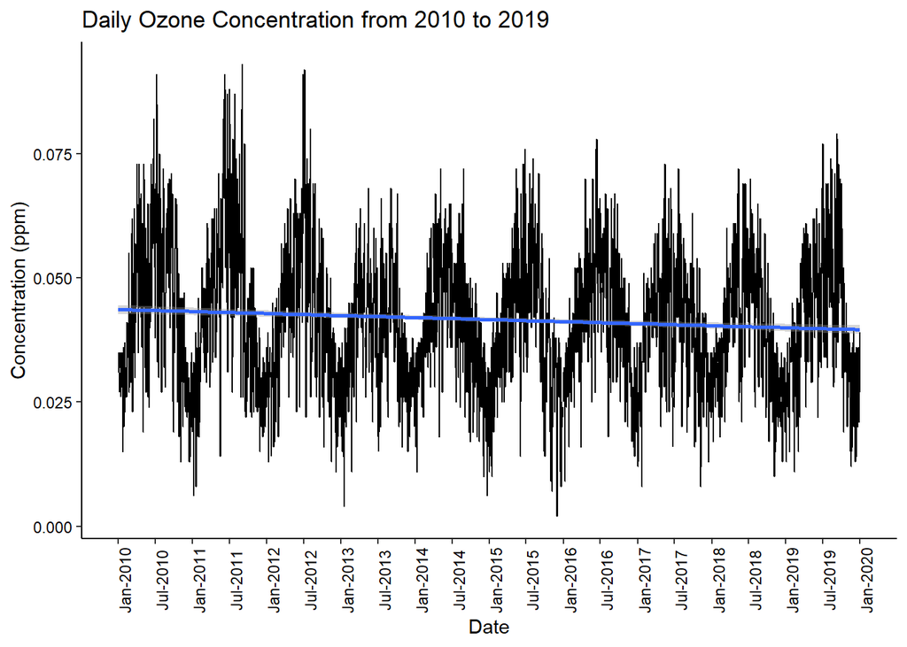

```r
# 7

ggplot(GaringerOzone, aes(x = Date, y = Daily.Max.8.hour.Ozone.Concentration)) +
    geom_line() + labs(x = "Date", y = "Concentration (ppm)") +
    geom_smooth(method = lm) + scale_x_date(date_breaks = "6 months",
    date_labels = "%b-%Y") + theme(axis.text.x = element_text(angle = 90)) +
    ggtitle("Daily Ozone Concentration from 2010 to 2019")
```

> **Answer:** at first sight, according to the graph ozone concentration shows a negative trend between 2010 and 2020.

## Time Series Analysis

Study question: Have ozone concentrations changed over the 2010s at this station?

8. Use a linear interpolation to fill in missing daily data for ozone concentration. Why didn’t we use a piecewise constant or spline interpolation?

```r
# 8

GaringerOzone$Daily.Max.8.hour.Ozone.Concentration <- na.approx(GaringerOzone$Daily.Max.8.hour.Ozone.Concentration)
```

> **Answer:** We use linear interpolation because we do not want to alter the time series structure, for instance, the minimum, maximum and mean values.
9. Create a new data frame called `GaringerOzone.monthly` that contains aggregated data: mean ozone concentrations for each month. In your pipe, you will need to first add columns for year and month to form the groupings. In a separate line of code, create a new Date column with each month-year combination being set as the first day of the month (this is for graphing purposes only)

```r
# 9

GaringerOzone.monthly <- GaringerOzone %>%
    mutate(Month = month(Date), Year = year(Date)) %>%
    mutate(Month_Year = my(paste0(Month, "-", Year))) %>%
    group_by(Month_Year) %>%
    summarize(mean_ozone_month = mean(Daily.Max.8.hour.Ozone.Concentration))
```

10. Generate two time series objects. Name the first `GaringerOzone.daily.ts` and base it on the dataframe of daily observations. Name the second `GaringerOzone.monthly.ts` and base it on the monthly average ozone values. Be sure that each specifies the correct start and end dates and the frequency of the time series.

```r
# 10


GaringerOzone.daily.ts <- ts(GaringerOzone$Daily.Max.8.hour.Ozone.Concentration,
    start = c(2010, 1, 1), frequency = 365)

GaringerOzone.monthly.ts <- ts(GaringerOzone.monthly$mean_ozone_month,
    start = c(2010, 1), frequency = 12)
```

11. Decompose the daily and the monthly time series objects and plot the components using the `plot()` function.

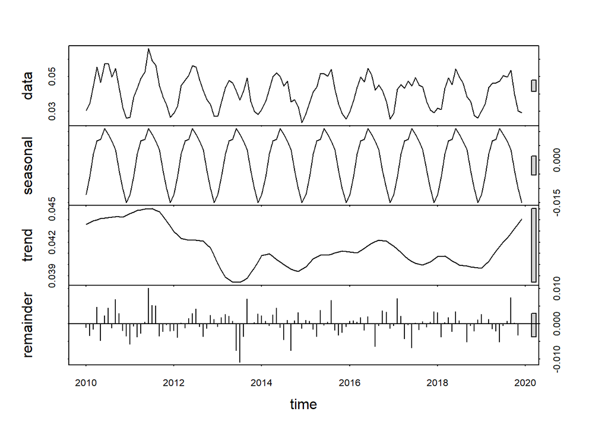

```r
# 11

GaringerOzone.monthly.ts.Decomposed <- stl(GaringerOzone.monthly.ts,
    s.window = "periodic")

plot(GaringerOzone.monthly.ts.Decomposed)
```

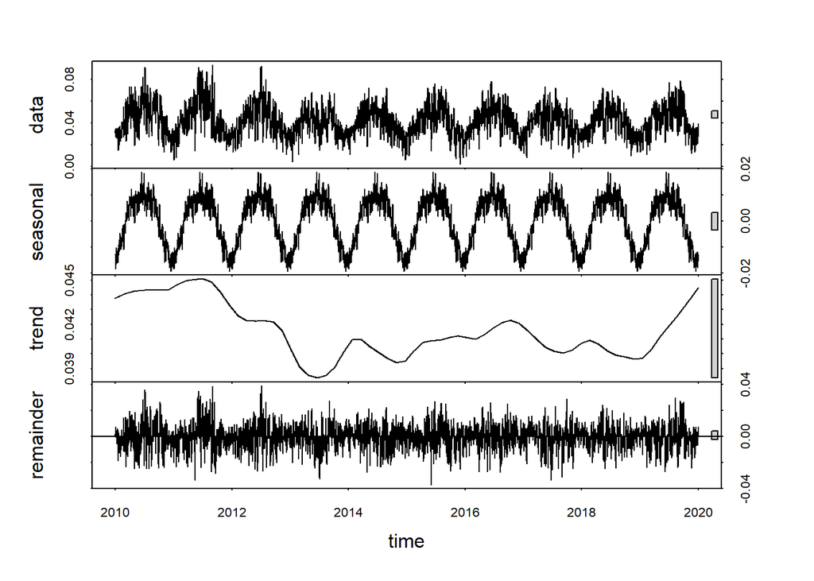

```r
GaringerOzone.daily.ts.Decomposed <- stl(GaringerOzone.daily.ts,
    s.window = "periodic")

plot(GaringerOzone.daily.ts.Decomposed)
```

12. Run a monotonic trend analysis for the monthly Ozone series. In this case the seasonal Mann-Kendall is most appropriate; why is this?

```r
# 12

GaringerOzone.monthly.ts.trend <- SeasonalMannKendall(GaringerOzone.monthly.ts)

GaringerOzone.monthly.ts.trend
```

```
## tau = -0.143, 2-sided pvalue =0.046724
```

```r
summary(GaringerOzone.monthly.ts.trend)
```

```
## Score =  -77 , Var(Score) = 1499
## denominator =  539.4972
## tau = -0.143, 2-sided pvalue =0.046724
```

> **Answer:** In this case, the most appropriate test is the Seasonal Mann Kendall, because the Garinger Ozone data has a strong seasonal component.
13. Create a plot depicting mean monthly ozone concentrations over time, with both a geom_point and a geom_line layer. Edit your axis labels accordingly.

```r
# 13

library(scales)
```

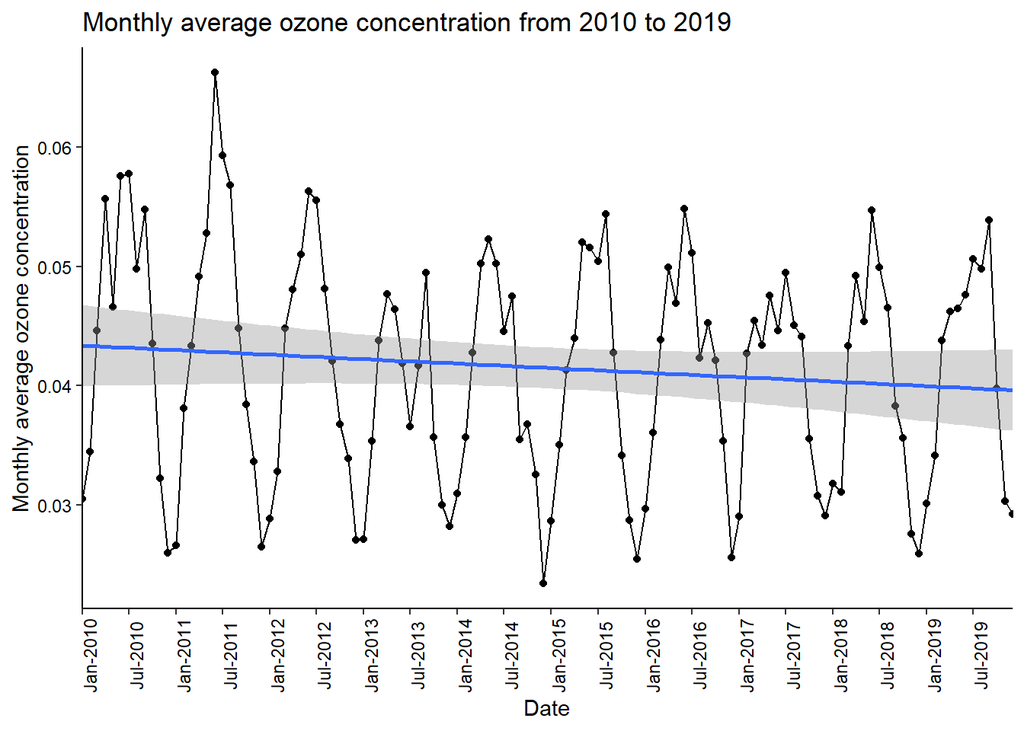

```r
monthly.avg.ozone.concentration.plot <- ggplot(GaringerOzone.monthly,
    aes(x = Month_Year, y = mean_ozone_month)) + geom_point() +
    geom_line() + ylab("Monthly average ozone concentration") +
    xlab("Date") + scale_x_date(date_breaks = "6 months",
    date_labels = "%b-%Y", expand = c(0, 0)) + theme(axis.text.x = element_text(angle = 90)) +
    geom_smooth(method = lm) + ggtitle("Monthly average ozone concentration from 2010 to 2019")

print(monthly.avg.ozone.concentration.plot)
```

```r
# 15

GaringerOzone.monthly.Components <- as.data.frame(GaringerOzone.monthly.ts.Decomposed$time.series[,
    1:3])

GaringerOzone.monthly.Components <- mutate(GaringerOzone.monthly.Components,
    Observed = GaringerOzone.monthly$mean_ozone_month,
    Date = GaringerOzone.monthly$Month_Year)


# 16
GaringerOzone.monthly.Components$trend.remainder <- GaringerOzone.monthly.Components$trend +
    GaringerOzone.monthly.Components$remainder

GaringerOzone.monthly.components.ts <- ts(GaringerOzone.monthly.Components$trend.remainder,
    start = c(2010, 1), frequency = 12)

GaringerOzone.monthly.components.ts.trend <- MannKendall(GaringerOzone.monthly.components.ts)

GaringerOzone.monthly.components.ts.trend
```

```
## tau = -0.165, 2-sided pvalue =0.0075402
```

```r
summary(GaringerOzone.monthly.components.ts.trend)
```

```
## Score =  -1179 , Var(Score) = 194365.7
## denominator =  7139.5
## tau = -0.165, 2-sided pvalue =0.0075402
```

> **Answer:** After running the Mann-Kendall test in the nonseasonal data, the result confirms that the time series has a decreasing trend. According to the Mann-Kendall test, we reject the null hypothesis that the series is stationary at a significance level of 5%.